# DATATHON

##### Detecting Pricing Anomalies

### IE MBD-O2

### TEAM C : Amartya | Ceci | Esteban | Iliana | Karim | Mike | Pau

[figure not shown]

## Approach Abstract

Detecting outliers or anomalies in pricing from the bookings data is an unsupervised learning problem. We will approach the problem with a three-pronged flow:

##### 1. Tag Explicit Errors and Meaningless Values

##### 2. Remove extreme values contrary to domain standards

##### 2. Check for statistical outliers based on calculated Outlier Score

##### 3. Cluster similar bookings based on pricipal components and detect statistical outliers

[figure not shown]

We proceed with the above approach while forming 2 basic assumption/hypothesis:

1. clusters or features that have higher standard deviations, kurtosis or extreme values are more likely to contain anomalies
2. Total anomalies will probably not be higher than 1% of the data set

The above approach is implemented by exploring the data set and at each level we create sub-sets of the data that are likely to be anomalies. In the end we combine all of these and create the final tag = 1 for anomalies, 0 for genuine.

1. Initialization
2. Basic Data Exploration,Feature Creation and Transformation
3. Feature Analysis
   1. ContractID
   2. Star Rating
   3. Room Type
   4. Arrival Month
   5. Category
   6. Meal Basis
   7. Contract Type
   8. Other Date Variables
   9. Time Variables
   10. City
   11. Hotel Key
4. Data Set Transformation
5. Outlier/Anomaly Detection
   1. Statistical and Visual Approach
   2. Clustering and Regression Approach
6. Anomaly Labeling and Submission

### Initialization

```python
# importing primary libraries
import numpy as np
import pandas as pd
from collections import Counter
import datetime as dt
import workdays
import glob
import datetime
import calendar
import matplotlib.pyplot as plt
import seaborn as sns
import sklearn.feature_selection
from sklearn import linear_model
from sklearn import metrics
from sklearn import preprocessing
from sklearn.decomposition import PCA
from sklearn.cluster import KMeans
%matplotlib inline
```

```python
# reading data set
df = pd.read_csv('DATATHON_STU_NEW.csv', index_col= 0)
df.head()
```

|  | hotel_hkey | contract_id_hkey | id_hkey | city_code | category_room | contract_type | room_type | meal_basis | creation_date | arrival_date | departure_date | total_cost | star_rating | row_id |
| --- | --- | --- | --- | --- | --- | --- | --- | --- | --- | --- | --- | --- | --- | --- |
| 0 | -8311839113995541010 | 3308171939935307043 | -6758561262332566539 | 1 | BL-6 | OPQ | APT | RO | 2018-05-22 | 2018-06-30 | 2018-07-05 | 14192.496000 | APARTMENT | 0 |
| 1 | -7782336419181110673 | -3269338087318960614 | -9183082468560560492 | 8 | ST | NOR | DBT | BB | 2018-05-22 | 2018-07-20 | 2018-07-24 | 3558.469200 | 1 | 1 |
| 2 | -8185637807857201025 | -7171383991101553094 | -573449065418159891 | 6 | XX-KG-SU | NOR | DBL | RO | 2018-05-22 | 2018-05-24 | 2018-05-29 | 17319.714354 | 5 | 2 |
| 3 | 4398388086357359587 | 3421074771505167982 | 215759992217563846 | 2 | ST | NONE | TWN | BB | 2018-05-22 | 2018-06-08 | 2018-06-11 | 3321.785004 | 3 | 3 |
| 4 | -7098207282290159573 | 7965439627984399332 | 1006074091123194605 | 7 | ST | NOR | DBT | RO | 2018-05-22 | 2018-06-11 | 2018-06-14 | 2586.300000 | 3 | 4 |

```python
# Checking properties of the data set
print(df.shape)
print(df.dtypes)
print(df.isnull().sum())
```

```
(899477, 14)
hotel_hkey            int64
contract_id_hkey      int64
id_hkey               int64
city_code             int64
category_room        object
contract_type        object
room_type            object
meal_basis           object
creation_date        object
arrival_date         object
departure_date       object
total_cost          float64
star_rating          object
row_id                int64
dtype: object
hotel_hkey             0
contract_id_hkey       0
id_hkey                0
city_code              0
category_room          0
contract_type          0
room_type              0
meal_basis             0
creation_date          0
arrival_date           0
departure_date         0
total_cost          8813
star_rating            0
row_id                 0
dtype: int64
```

### Basic Data Exploration,Feature Creation and Transformation

We begin with exploring the data set. We first remove the obvious anomalies (step 1 of our approach) which are the Nulls and negetive prices

```python
# Imputing nulls, negatives and zero values for costs into an 'anomaly' Data Frame.
df_anomaly1 = df.loc[(df.total_cost <= 0) | (df.total_cost.isnull()),:]
df = df.loc[df.total_cost.notnull(), :]
df = df.loc[df.total_cost > 0, :]
```

```python
df_anomaly1.shape
```

```
(8820, 14)
```

Date variable has a lot of features hidden, we extract them and create new feature variables such as month, day etc for arrival, departure and booking

```python
# Function definition for extracting days from delta time
def extractDays(td):
    return td.days

# Function to calculate working days between 2 dates
def cal_weekdays(a):
    return(workdays.networkdays(pd.to_datetime(a[0]),pd.to_datetime(a[1])))
```

```python
# Create basic features out of the provided date variable
df["creation_date_month"] = pd.DatetimeIndex(pd.to_datetime(df['creation_date'])).month
df["creation_date_day"] = pd.DatetimeIndex(pd.to_datetime(df['creation_date'])).day
df["creation_date_weekday"] = pd.DatetimeIndex(pd.to_datetime(df['creation_date'])).weekday

df["arrival_date_month"] = pd.DatetimeIndex(pd.to_datetime(df['arrival_date'])).month
df["arrival_date_day"] = pd.DatetimeIndex(pd.to_datetime(df['arrival_date'])).day
df["arrival_date_weekday"] = pd.DatetimeIndex(pd.to_datetime(df['arrival_date'])).weekday

df["departure_date_month"] = pd.DatetimeIndex(pd.to_datetime(df['departure_date'])).month
df["departure_date_day"] = pd.DatetimeIndex(pd.to_datetime(df['departure_date'])).day
df["departure_date_weekday"] = pd.DatetimeIndex(pd.to_datetime(df['departure_date'])).weekday
```

Using the variables previously created we decided to come up with new features based on the departure_date, arrival_date and creation_date:

'**TripNoOfDays**' the duration of the trip

'**begEnd**' tuple of arrival_date and departure_date

'**TripWorkingDays**' number of working days during the trip

'**TripWeekends**' number of weekends during the trip

'**BookingLeadTime**' Lead time between booking and start of the trip

```python
df["TripNoOfDays"] = pd.DatetimeIndex(pd.to_datetime(df.departure_date)) - pd.DatetimeIndex(pd.to_datetime(df.arrival_date))

df.TripNoOfDays =  df.TripNoOfDays.apply(extractDays)
df.TripNoOfDays = df.TripNoOfDays + 1

df['begEnd'] = df[['arrival_date', 'departure_date']].apply(tuple, axis=1)
df["TripWorkingDays"]  = df.begEnd.apply(cal_weekdays)
df["TripWeekends"] =   df.TripNoOfDays -  df.TripWorkingDays
df.loc[df.TripWeekends < 0,'TripWeekends'] = 0

df["BookingLeadTime"] = pd.DatetimeIndex(pd.to_datetime(df.arrival_date)) - pd.DatetimeIndex(pd.to_datetime(df.creation_date))
df.BookingLeadTime =  df.BookingLeadTime.apply(extractDays)
```

```python
# Create feature 'price/cost' per night
df["PricePerNight"] = df.total_cost / df.TripNoOfDays
df["PricePerNight"] = df.PricePerNight.apply(int)
```

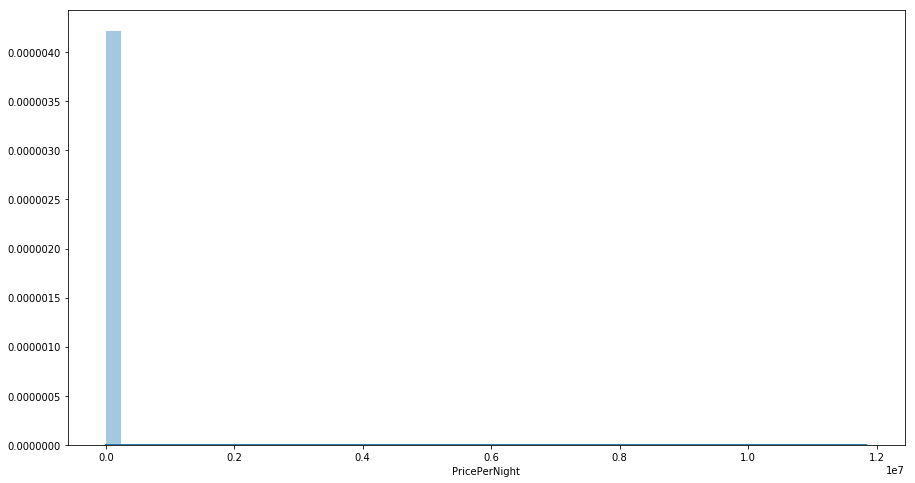

```python
# Plot the distribution of 'PriceperNight' in millions
plt.figure(figsize=(15,8))
sns.distplot(df.loc[:,'PricePerNight']);
```

```python
# New list that comprises all the categorical variables from the Data Frame
categoricalVariables = ['city_code','category_room','contract_type','room_type','meal_basis',
                       'creation_date_month', 'creation_date_day',
                       'creation_date_weekday', 'arrival_date_month', 'arrival_date_day',
                       'arrival_date_weekday', 'departure_date_month', 'departure_date_day',
                       'departure_date_weekday','star_rating']

# Change the variable type of the previous list to 'category'
for i in categoricalVariables:
    df[i] = df[i].astype('category')
```

```python
# Delete the variables we no longer need
df = df.drop(['id_hkey', 'creation_date', 'arrival_date', 'departure_date', 'begEnd', 'total_cost'], axis = 1)
```

#### Exploring the distribution of Variables

```python
# Create two new Data Frames containing all the categorical and numerical features, respectively
categoricalVariables = df.select_dtypes(include=['category']).columns
numericalVariables = df.select_dtypes(include=['int64']).columns
```

```python
#Describe all the columns
columnNames = df.columns
for i in columnNames:
    print(i)
    print(df[i].describe())
```

```
hotel_hkey
count    8.906570e+05
mean     1.197551e+16
std      5.235581e+18
min     -9.221152e+18
25%     -4.536184e+18
50%      2.100855e+17
75%      4.423175e+18
max      9.220866e+18
Name: hotel_hkey, dtype: float64
contract_id_hkey
count    8.906570e+05
mean     4.422421e+17
std      5.067546e+18
min     -9.223151e+18
25%     -3.949640e+18
50%      1.474372e+18
75%      3.766924e+18
max      9.222155e+18
Name: contract_id_hkey, dtype: float64
city_code
count     890657
unique         9
top            7
freq      174059
Name: city_code, dtype: int64
category_room
count     890657
unique      1320
top           ST
freq      407103
Name: category_room, dtype: object
contract_type
count     890657
unique         7
top          NOR
freq      494540
Name: contract_type, dtype: object
room_type
count     890657
```

[output cut: 115 more lines]

```
25%          10.000000
50%          35.000000
75%          89.000000
max         756.000000
Name: BookingLeadTime, dtype: float64
PricePerNight
count    8.906570e+05
mean     1.198061e+03
std      1.287194e+04
min      0.000000e+00
25%      5.060000e+02
50%      8.870000e+02
75%      1.494000e+03
max      1.184651e+07
Name: PricePerNight, dtype: float64
```

```python
# Drop variables that are no longer needed
categoricalVariables = categoricalVariables.drop(['category_room'])
numericalVariables = numericalVariables.drop(['row_id','hotel_hkey','contract_id_hkey'])
```

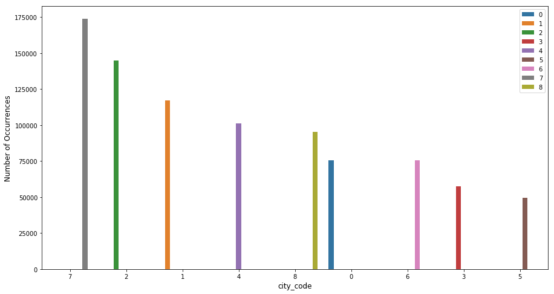

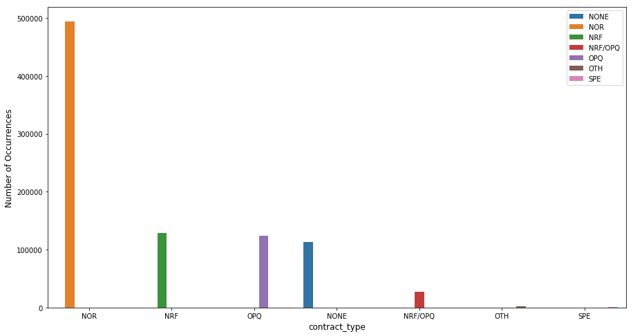

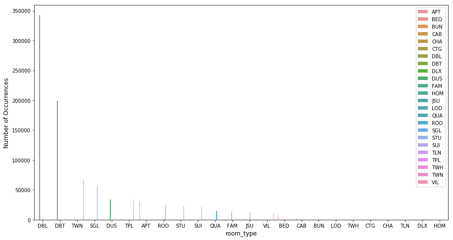

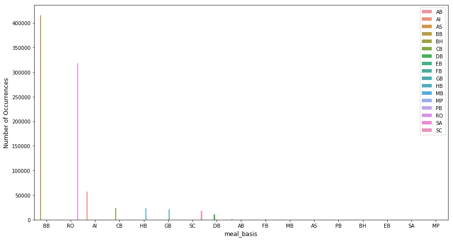

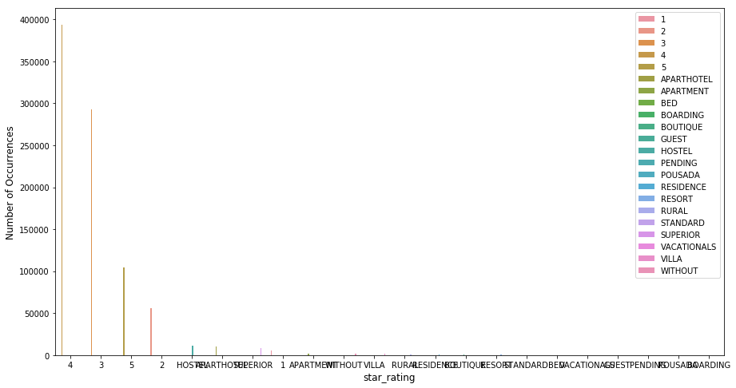

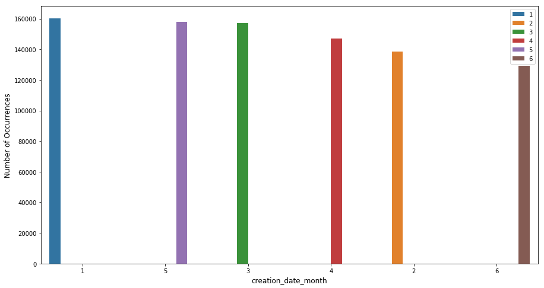

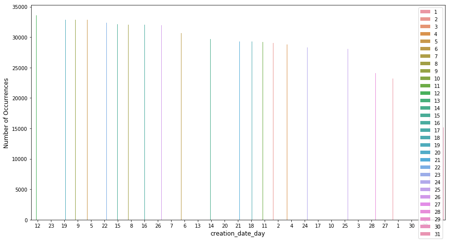

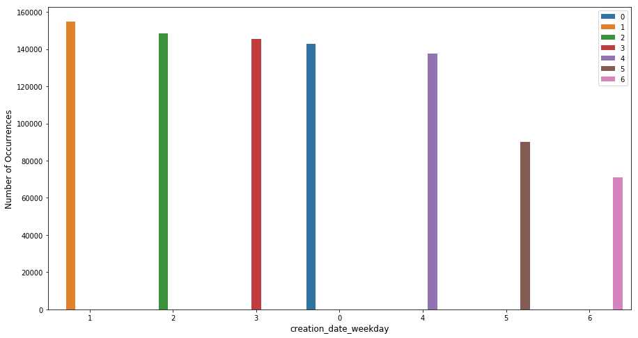

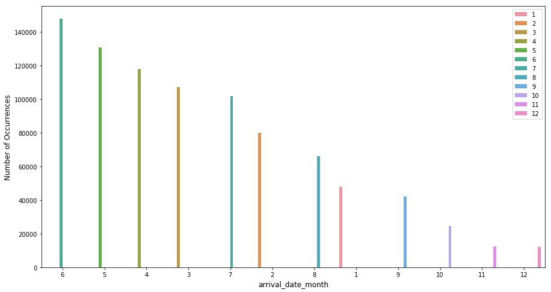

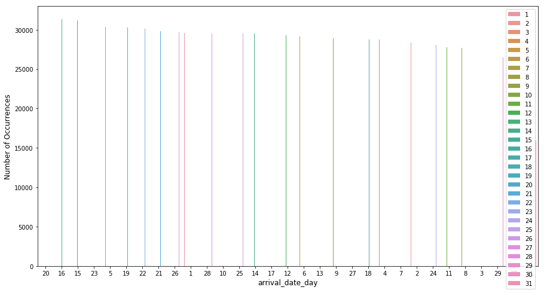

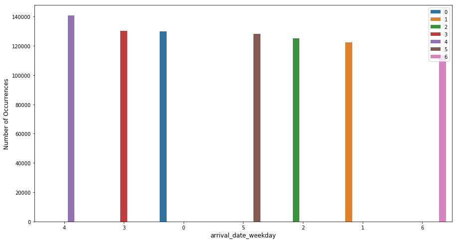

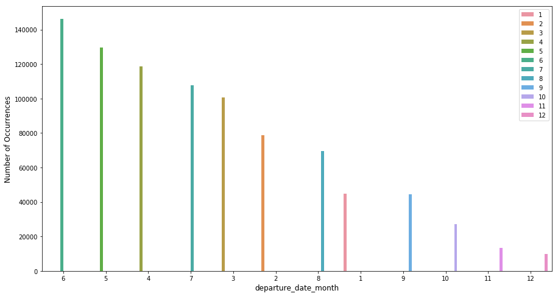

[2 more figures not shown]

```python
# Visualize the count of occurrences by categories
for i,col in enumerate(categoricalVariables):
    plt.figure(i,figsize=(15,8))
    sns.countplot(df[col],hue = df[col], order=df[col].value_counts().index)
    plt.legend(loc='upper right')
    plt.ylabel('Number of Occurrences', fontsize=12)
    plt.xlabel(col, fontsize=12)
    plt.show()
```

We can see here that for many of the categorical variables the distribution/ count is extremely skewed towards a minor group of categories (levels). This provides some evidence to our hypothesis that low count categories with out of normal range prices may be anomalous in nature. Alternatively they can be realistic outliers and not anomalies.

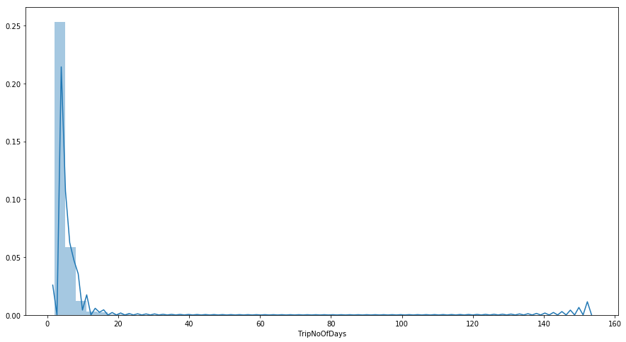

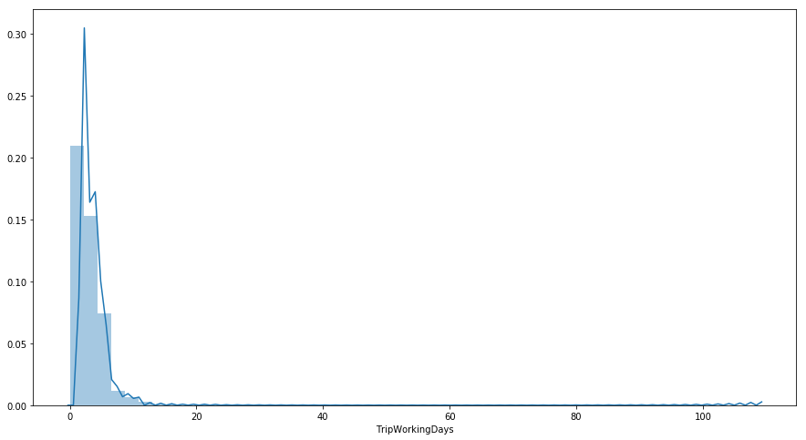

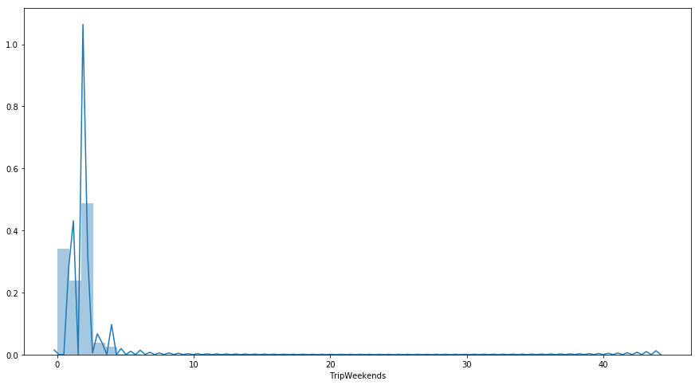

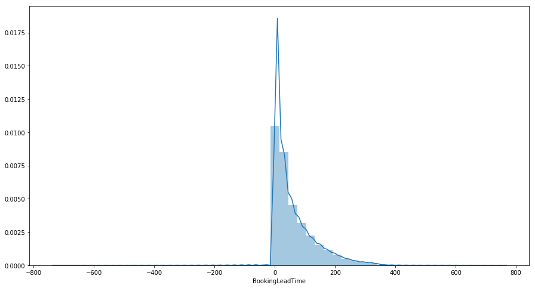

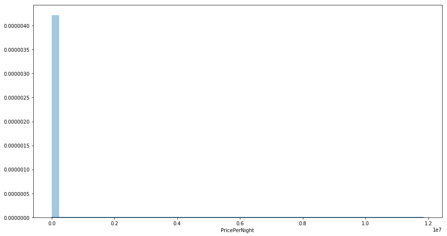

```python
# Plot the distribution of the numerical variables
for i, col in enumerate(numericalVariables):
    plt.figure(i, figsize=(15,8))
    sns.distplot(df.loc[:,col])
```

In booking lead time, we can observe a left tail corresponding to negative lead times, which are anomalies. However, this anomalies are not price related, this is why we will not include them in the final prediction.

```python
# Description of the price per nigt variable and the cut-off point of the 99.995 percentile
print(df.PricePerNight.describe())
print(np.percentile(df.PricePerNight, 99.995))
```

```
count    8.906570e+05
mean     1.198061e+03
std      1.287194e+04
min      0.000000e+00
25%      5.060000e+02
50%      8.870000e+02
75%      1.494000e+03
max      1.184651e+07
Name: PricePerNight, dtype: float64
26668.027199981036
```

```python
# Number of the points on the left of the 0.005 percentile
print(np.percentile(df.PricePerNight, 0.005))
```

```
37.0
```

###### We see that the skew is denser upto 99%ile and becomes sparse at higher percentiles. Using basic statistical concepts related to normal distribution, we can assume price values above 99.995%iles as outliers with higher confidence levels. The same statistical rule can be applied on the lower side of the price band.

```python
# Number of the points on the left of the 0.01 percentile OR on the right of the 99.995 percentile
df.loc[(df.PricePerNight > np.percentile(df.PricePerNight, 99.995)) | (df.PricePerNight < np.percentile(df.PricePerNight, 0.01)) , :].shape
```

```
(112, 23)
```

```python
# Saving the previous instances into a new Data Frame
df_anomaly2 = df.loc[(df.PricePerNight > np.percentile(df.PricePerNight, 99.995)) | (df.PricePerNight < np.percentile(df.PricePerNight, 0.01)) , :]
df = df.loc[(df.PricePerNight < np.percentile(df.PricePerNight, 99.995)) & (df.PricePerNight > np.percentile(df.PricePerNight, 0.01)) , :]
```

```python
df.shape
```

```
(890510, 23)
```

```python
df_anomaly2.describe()
```

|  | hotel_hkey | contract_id_hkey | row_id | TripNoOfDays | TripWorkingDays | TripWeekends | BookingLeadTime | PricePerNight |
| --- | --- | --- | --- | --- | --- | --- | --- | --- |
| count | 1.120000e+02 | 1.120000e+02 | 112.000000 | 112.000000 | 112.000000 | 112.000000 | 112.000000 | 1.120000e+02 |
| mean | 2.223070e+17 | -1.077970e+18 | 445401.535714 | 7.946429 | 5.660714 | 2.285714 | 64.812500 | 1.655922e+05 |
| std | 4.314218e+18 | 5.675313e+18 | 258670.342395 | 18.569974 | 13.152983 | 5.469701 | 89.652636 | 1.136739e+06 |
| min | -8.994413e+18 | -9.082922e+18 | 23073.000000 | 2.000000 | 0.000000 | 0.000000 | -211.000000 | 0.000000e+00 |
| 25% | -2.490838e+18 | -8.130374e+18 | 241584.500000 | 2.000000 | 2.000000 | 0.000000 | 7.000000 | 3.600000e+01 |
| 50% | 9.155799e+17 | 8.395429e+17 | 454958.000000 | 2.000000 | 2.000000 | 1.000000 | 34.500000 | 3.900000e+01 |
| 75% | 2.090897e+18 | 3.421075e+18 | 624530.500000 | 6.000000 | 5.000000 | 2.000000 | 85.250000 | 3.138950e+04 |
| max | 8.989539e+18 | 8.557785e+18 | 897293.000000 | 153.000000 | 109.000000 | 44.000000 | 361.000000 | 1.184651e+07 |

```python
# Count of anomalies inside the dataframe 'df_anomaly2'
df_anomaly2.contract_id_hkey.unique().size
```

```
32
```

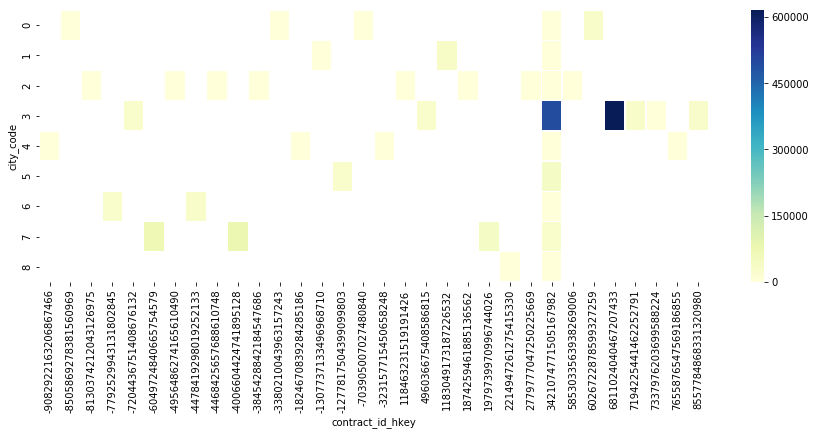

```python
# Heatmap of the cities per hotel against its price
plt.figure(figsize=(15,5))
sns.heatmap(df_anomaly2.groupby(["city_code", "contract_id_hkey"])['PricePerNight'].min().unstack()
            ,linewidths=.5, cmap="YlGnBu");
```

Clearly they are mostly outliers among this sub data set. For now we can treat them as anomalies.

```
Text(0,0.5,'PricePerNight')
```

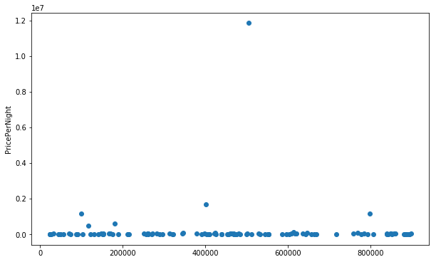

```python
# Scatter plot of the anomalies compressed per night in the Data Frame 'df_anomaly2'
plt.figure(figsize=(10,6))
plt.scatter(df_anomaly2.index,df_anomaly2.PricePerNight)
plt.ylabel('PricePerNight')
```

### Feature Analysis

#### Contract ID Key

##### The contract ID key represents a aggregation of properties of the booking based on the variables related to the hotel such as hotel, contract type, room type, meal basis and so on. Hence it is a good idea to create mean, median and standard deviation of the records grouped by the contract id. We can use the displacement of the price from these median values (considering the std dev and mean) as indicators of possible outliers or potential anomalies

```python
# Mean 'PricePerNight' grouped by all the contracts id's
contractIdMean = df.groupby(['contract_id_hkey'])['PricePerNight'].mean()
```

```python
# Function to return mean of each contract
def getContractMean(cid):
    return(contractIdMean[cid])
```

```python
# New column to store the difference between the 'PricePerNight' and the newly created 'ContractIdMean'
df['ContractIdMean'] = df.contract_id_hkey.apply(getContractMean)
df['priceDifbyContractMean'] = df['PricePerNight'] - df['ContractIdMean']
#df = df.drop(['ContractIdMean'], axis = 1)
```

#### Star Rating

```python
# Description of the variable
df.star_rating.describe()
```

```
count     890510
unique        22
top            4
freq      393941
Name: star_rating, dtype: object
```

We see that the hotel star rating can be converted to ordinal scale of 1 to 5. For this we compare the median prices of each non numbered category with values of the star ratings for each of the corresponding cities/star. This way we can rank the non numbered star rating categories into numbered star ratings

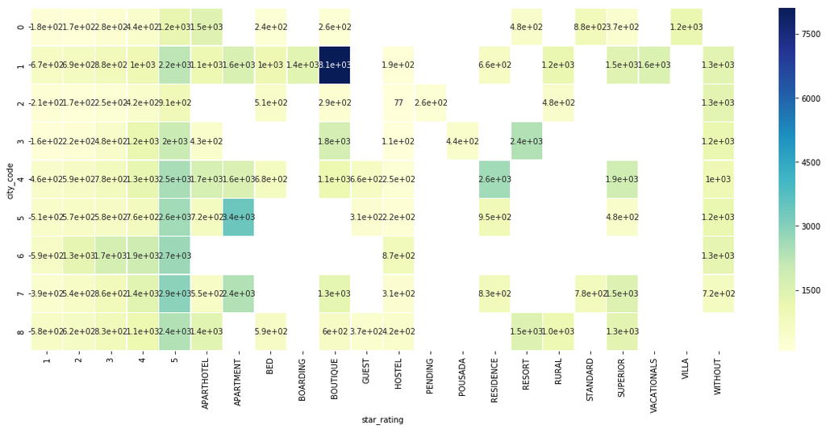

```python
# Heatmap of the 'star_rating' per city against its 'PricePerNight'
plt.figure(figsize=(20,8))
sns.heatmap(df.groupby(["city_code", "star_rating"])['PricePerNight'].median().unstack()
            ,linewidths=.5, cmap="YlGnBu", annot=True);
```

Based on the PricePerNight similarities between cities and star_rating, we grouped them and simplified the amount of categories from 22 to 5: (1,2,3,4,5) as HotelStarRating

```python
# Rules for Star Rating
Hotelratings = {
                ("APARTHOTEL",0): 5, ("APARTHOTEL",1): 4, ("APARTHOTEL",3): 3, ("APARTHOTEL",4): 4, ("APARTHOTEL",5): 4,
                ("APARTHOTEL",7): 2, ("APARTHOTEL",8): 4, ("APARTMENT",1): 4, ("APARTMENT",4): 4, ("APARTMENT",5): 5,
                ("APARTMENT",7): 4, ("BED",0): 1, ("BED",1): 4, ("BED",2): 4, ("BED",4): 3, ("BED",8): 1, ("BOARDING",1): 4,
                ("BOUTIQUE",0): 3, ("BOUTIQUE",1): 1, ("BOUTIQUE",2): 3, ("BOUTIQUE",3): 5, ("BOUTIQUE",4): 4,
                ("BOUTIQUE",7): 4, ("BOUTIQUE",8): 1, ("GUEST",4): 2, ("GUEST",5): 1, ("GUEST",8): 1, ("HOSTEL",1): 1,
                ("HOSTEL",2): 1, ("HOSTEL",3): 1, ("HOSTEL",4): 1, ("HOSTEL",5): 1, ("HOSTEL",6): 1, ("HOSTEL",7): 1,
                ("HOSTEL",8): 1, ("PENDING",2): 3, ("POUSADA",3): 3, ("RESIDENCE",1): 1, ("RESIDENCE",4): 5,
                ("RESIDENCE",5): 4, ("RESIDENCE",7): 3, ("RESORT",0): 4, ("RESORT",3): 5, ("RESORT",8): 4, ("RURAL",1): 4,
                ("RURAL",2): 4, ("RURAL",8): 4, ("STANDARD",0): 4, ("STANDARD",7): 3, ("SUPERIOR",7): 4, ("SUPERIOR",8): 4,
                ("SUPERIOR",4): 4, ("SUPERIOR",0): 4, ("SUPERIOR",1): 4, ("SUPERIOR",5): 1, ("VACATIONALS",1): 4,
                ("VILLA",0): 5, ("WITHOUT",1): 4, ("WITHOUT",2): 5, ("WITHOUT",3): 4, ("WITHOUT",4): 4, ("WITHOUT",5): 4,
                ("WITHOUT",6): 4, ("WITHOUT",7): 4
                }
```

```python
# Function to Return the Star rating of the booked Hotel based on the above Rule
def getRating(t):
    return(Hotelratings[t])
```

```python
# Create new variable 'combo' containing a touple with the 'star_rating' and the 'city_code'
df['combo'] = df[['star_rating', 'city_code']].apply(tuple, axis=1)

# Application of the aforementioned rules into the new feature 'HotelStarRating'
df['HotelStarRating'] = 0
df.loc[df.star_rating.isin(['5','4','3','2','1']),'HotelStarRating'] = df.star_rating
df.loc[df.HotelStarRating == 0, 'HotelStarRating'] =  df.loc[df.HotelStarRating == 0, :].combo.apply(getRating)
df.HotelStarRating = df.HotelStarRating.astype(int)
```

```python
# Edit the variable 'star_rating'so that it returns 'HOTEL' if the instance contains a number of stars
df.star_rating = df.star_rating.astype('object')
df.loc[df.star_rating.isin(['5','4','3','2','1']),'star_rating'] = 'HOTEL'
```

```python
df.star_rating.describe()
```

```
count     890510
unique        18
top        HOTEL
freq      852609
Name: star_rating, dtype: object
```

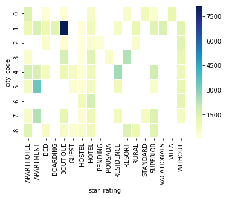

```python
# Heatmap of the edited 'star_rating' variable per city against its price
sns.heatmap(df.groupby(["city_code", "star_rating"])['PricePerNight'].median().unstack()
            ,linewidths=.5, cmap="YlGnBu");
```

```python
# Return the median and standard deviation of the 'PricePerNight' grouped by the 'star_rating'
print(df.groupby(["star_rating"])['PricePerNight'].median().sort_values(ascending = False))
#print(df.groupby(["star_rating"])['PricePerNight'].mean().sort_values(ascending = False))
print(df.groupby(["star_rating"])['PricePerNight'].std().sort_values(ascending = False))
```

```
star_rating
APARTMENT      1656.0
VACATIONALS    1557.5
BOARDING       1379.0
SUPERIOR       1284.0
VILLA          1174.5
BOUTIQUE        990.5
APARTHOTEL      945.0
WITHOUT         916.0
RURAL           910.0
HOTEL           891.0
STANDARD        837.5
RESIDENCE       820.0
BED             757.0
RESORT          486.0
POUSADA         444.0
GUEST           371.0
PENDING         260.0
HOSTEL          236.0
Name: PricePerNight, dtype: float64
star_rating
WITHOUT        1280.696048
SUPERIOR       1219.795228
BOUTIQUE       1158.462282
HOTEL          1121.532422
RESIDENCE      1081.333859
VACATIONALS    1034.681381
APARTMENT      1006.623238
VILLA           947.661850
APARTHOTEL      829.324959
RURAL           751.599248
BED             558.204820
RESORT          544.525513
GUEST           469.019514
HOSTEL          360.177856
STANDARD        342.774811
POUSADA          63.720745
PENDING          53.702886
BOARDING               NaN
Name: PricePerNight, dtype: float64
```

```python
# Remove the variable 'combo' as we will no longer use it
df = df.drop(['combo'], axis = 1)
```

The type of hotel is not revealing much information. We will thus continue with using the ordinal scale from 1 : 5 as that has greater relevance for understanding the pricing

#### Room Type

For room type we will take a standard approach of checkinig which room types have higher prices (on an average or as per median). Using this as a metric we will convert the categories into a ranked numerical scale which can have a better correlation to the prices

```python
# Describing the median of 'PricePerNight' per 'room_type' and count of the records in each type of room
print(df.groupby(["room_type"])['PricePerNight'].median().sort_values(ascending = False))
Counter(df['room_type']).most_common(26)
```

```
room_type
TWH    2481.0
DLX    2020.0
JSU    2002.0
CHA    1813.5
LOD    1467.0
CAB    1402.0
VIL    1381.5
FAM    1342.0
SUI    1306.0
CTG    1232.0
TPL    1230.0
APT    1200.0
ROO    1190.0
QUA    1127.0
DBL    1027.0
TLN     935.0
BUN     915.5
TWN     780.0
STU     771.0
DUS     708.0
SGL     692.0
HOM     686.0
DBT     628.0
BED     167.5
Name: PricePerNight, dtype: float64
```

```
[('DBL', 342498),
 ('DBT', 198754),
 ('TWN', 66209),
 ('SGL', 55282),
 ('DUS', 33505),
 ('TPL', 33300),
 ('APT', 30830),
 ('ROO', 24640),
 ('STU', 22427),
 ('SUI', 21201),
 ('QUA', 14866),
 ('FAM', 14165),
 ('JSU', 12219),
 ('VIL', 10704),
 ('BED', 8138),
 ('CAB', 1147),
 ('BUN', 422),
 ('LOD', 86),
 ('TWH', 45),
 ('CTG', 39),
 ('CHA', 16),
 ('TLN', 15),
 ('DLX', 1),
 ('HOM', 1)]
```

```python
# Creation of a new Data Frame containing the median of the 'PricePerNight' per 'room_type'
medianPriceByRoomType = df.groupby(["room_type"])['PricePerNight'].median().sort_values(ascending = False)
```

```python
# Add this feature into the main Data Frame
df['MedianPriceByRoomType'] = 0
for i in medianPriceByRoomType.index:
    df.loc[df.room_type == i,'MedianPriceByRoomType'] = medianPriceByRoomType[i]
```

#### Arrival Month

Based on our understanding of tourism industry we have an hypothesis that PricePerNight tends to be higher in summer break months and december. We will go ahead and explore the distribution of prices by arrival month and verify this

```
HotelStarRating         1       2      3       4       5
arrival_date_month
1                   188.0   354.0  484.0   652.0  1451.0
2                   216.5   384.0  524.0   722.0  1477.0
3                   297.5   471.0  618.0   806.0  1543.0
4                   293.0   517.0  659.0   896.0  1512.0
5                   330.0   571.0  703.0   968.0  1534.0
6                   382.5   681.0  794.0  1063.0  1570.0
7                   502.0   875.0  961.0  1321.0  1863.0
8                   601.0   940.0  937.0  1329.0  1733.0
9                   452.0   762.0  957.0  1324.0  1604.5
10                  370.5   683.0  896.0  1267.0  1578.0
11                  388.0   629.0  733.0  1298.0  1648.5
12                  332.5  1298.0  838.0  1591.5  2230.0
```

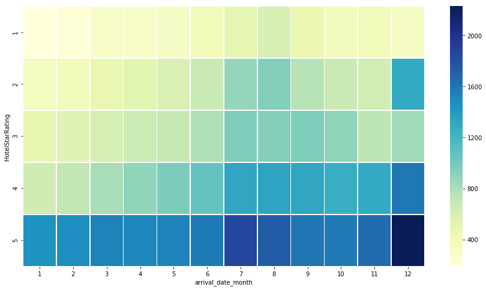

```python
# matrix of the 'PricePerNight' by 'HotelStarRating' and 'arrival_date_month'
print(df.groupby(["arrival_date_month", "HotelStarRating"])['PricePerNight'].median().unstack())

# Heatmap of the edited 'arrival_date_month' variable per 'HotelStarRating' against its price
plt.figure(figsize=(15,8))
sns.heatmap(df.groupby(["HotelStarRating","arrival_date_month"])['PricePerNight'].median().unstack()
            ,linewidths=.5, cmap="YlGnBu");
```

Based in the heatmap we confirm that the previous statement is true, and now a new varible will be created to group months with simital prices and a rank will be assigned based on price.

```python
# New feature 'monthRating' that group months with similar prices
df['monthRating'] = 0
df.loc[df.arrival_date_month.isin(['1','2']), 'monthRating'] = 1
df.loc[df.arrival_date_month.isin(['3','4','5']), 'monthRating'] = 5
#df.loc[df.arrival_date_month.isin(['11','12']), 'monthRating'] = 4
df.loc[df.arrival_date_month.isin(['6','9','10','11']), 'monthRating'] = 25
df.loc[df.arrival_date_month.isin(['7','8','12']), 'monthRating'] = 75
```

#### Category Room

A similar ranking apporoach will be used for category of the room as well. Since it has > 1000 category levels, not much information can be extracted apart from converting it to an ordinal scale of values

```python
# Count the number instances in each factor
Counter(df['category_room']).most_common(1319)
```

```
[('ST', 407086),
 ('DX', 70748),
 ('SU', 31359),
 ('SU-1', 30080),
 ('AS', 22661),
 ('XX-SU', 22422),
 ('SP', 18114),
 ('QN', 11314),
 ('ST-1', 9617),
 ('KG', 8293),
 ('C2', 7554),
 ('OM', 7431),
 ('VM', 7139),
 ('EJ', 6681),
 ('GD', 6572),
 ('PE', 5667),
 ('EY', 5045),
 ('PI', 4759),
 ('XX-2B', 4735),
 ('OV', 4484),
 ('DX-1', 4427),
 ('XX-1B', 4073),
 ('B1', 4061),
 ('DX-KG', 4019),
 ('LX', 3710),
 ('B2', 3533),
 ('NM', 3508),
 ('1B-1', 3417),
 ('DB', 3039),
 ('C3', 3008),
 ('Z1', 2991),
 ('1B', 2866),
 ('PR', 2678),
 ('2D', 2664),
 ('B1-C4', 2578),
 ('XX-GR', 2549),
 ('IN', 2542),
 ('BL', 2505),
 ('C4', 2464),
 ('ST-2', 2343),
```

[output cut: 946 more lines]

```
 ('DX-SM', 5),
 ('RV-SU', 5),
 ('TR-2', 5),
 ('3H', 5),
 ('BR', 5),
 ('C4-3', 5),
 ('1B-PO-RY-VI', 5),
 ('AE-DX-LG', 5),
 ('GL-KG', 5),
 ('B2-PE', 5),
 ('2B-3K-SU', 4),
 ('WC', 4),
 ('SM-VJ', 4),
 ('GN-SD', 4),
 ...]
```

```python
# New Data Frame containing the median 'PricePerNight' be 'category_room'
categoryRoomPriceRank = df.groupby(["category_room"])['PricePerNight'].median().sort_values(ascending = False)
```

```python
# Creating rank for records based on 'room_category'
categoryRoomPriceRank = categoryRoomPriceRank.fillna(0)
maxi = max(categoryRoomPriceRank)
categoryRoomPriceRank = (categoryRoomPriceRank/maxi) * 100
categoryRoomPriceRank = categoryRoomPriceRank.astype(int)
```

```python
# Adding this feature to the main Data Frame
df['categoryRoomPriceRank'] = 0
for i in categoryRoomPriceRank.index:
    df.loc[df.category_room == i,'categoryRoomPriceRank'] = categoryRoomPriceRank[i]
```

```python
df.star_rating.describe()
```

```
count     890510
unique        18
top        HOTEL
freq      852609
Name: star_rating, dtype: object
```

#### Meal Basis

Meal basis will obviously have an influence on the price of the bookings. We can explore which meal categories are higher priced in general. Using this information we can create a score to force a postive correlation between meal basis and price per night

```python
df.head()
```

|  | hotel_hkey | contract_id_hkey | city_code | category_room | contract_type | room_type | meal_basis | star_rating | row_id | creation_date_month | ... | TripWorkingDays | TripWeekends | BookingLeadTime | PricePerNight | ContractIdMean | priceDifbyContractMean | HotelStarRating | MedianPriceByRoomType | monthRating | categoryRoomPriceRank |
| --- | --- | --- | --- | --- | --- | --- | --- | --- | --- | --- | --- | --- | --- | --- | --- | --- | --- | --- | --- | --- | --- |
| 0 | -8311839113995541010 | 3308171939935307043 | 1 | BL-6 | OPQ | APT | RO | APARTMENT | 0 | 5 | ... | 4 | 2 | 39 | 2365 | 1434.529412 | 930.470588 | 4 | 1200.0 | 25 | 7 |
| 1 | -7782336419181110673 | -3269338087318960614 | 8 | ST | NOR | DBT | BB | HOTEL | 1 | 5 | ... | 3 | 2 | 59 | 711 | 693.830000 | 17.170000 | 1 | 628.0 | 75 | 3 |
| 2 | -8185637807857201025 | -7171383991101553094 | 6 | XX-KG-SU | NOR | DBL | RO | HOTEL | 2 | 5 | ... | 4 | 2 | 2 | 2886 | 3324.400000 | -438.400000 | 5 | 1027.0 | 5 | 4 |
| 3 | 4398388086357359587 | 3421074771505167982 | 2 | ST | NONE | TWN | BB | HOTEL | 3 | 5 | ... | 2 | 2 | 17 | 830 | 1582.198613 | -752.198613 | 3 | 780.0 | 25 | 3 |
| 4 | -7098207282290159573 | 7965439627984399332 | 7 | ST | NOR | DBT | RO | HOTEL | 4 | 5 | ... | 4 | 0 | 20 | 646 | 518.577053 | 127.422947 | 3 | 628.0 | 25 | 3 |

5 rows × 29 columns

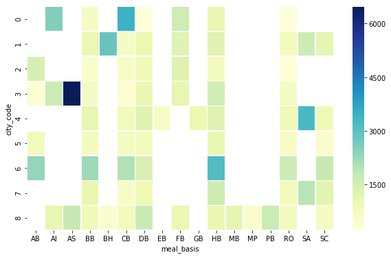

```python
plt.figure(figsize=(10,6))
sns.heatmap(df.groupby(["city_code","meal_basis"])['PricePerNight'].median().sort_values(ascending= False).unstack()
            ,linewidths=.5, cmap="YlGnBu");
```

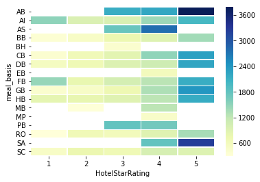

```python
sns.heatmap(df.groupby(["meal_basis", "HotelStarRating"])['PricePerNight'].median().unstack()
            ,linewidths=.5, cmap="YlGnBu");
```

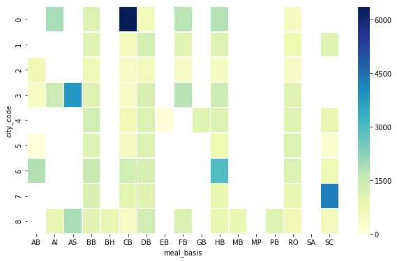

```python
plt.figure(figsize=(10,6))
sns.heatmap(df.groupby(["city_code","meal_basis"])['PricePerNight'].std().sort_values(ascending= False).unstack()
            ,linewidths=.5, cmap="YlGnBu");
```

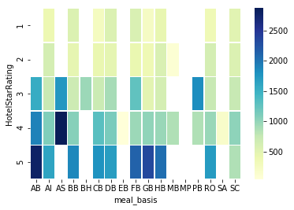

```python
sns.heatmap(df.groupby([ "HotelStarRating","meal_basis"])['PricePerNight'].std().unstack()
            ,linewidths=.5, cmap="YlGnBu");
```

```python
# New feature for scoring based on the deviation of price from median grouped by 'mealBasis'
df['mealBasisDeviation'] = 1
df.loc[df.meal_basis.isin(['CB','FB','DB']),'mealBasisDeviation'] = 5
df.loc[df.meal_basis.isin(['HB','SC']),'mealBasisDeviation'] = 2
```

```python
df.groupby(["meal_basis"])['PricePerNight'].median().sort_values(ascending = False)
```

```
meal_basis
AB    2223
SA    1929
AS    1844
PB    1692
AI    1502
MB    1171
FB    1151
HB    1077
DB    1062
GB     995
CB     873
BB     869
RO     773
SC     740
EB     607
MP     478
BH     434
Name: PricePerNight, dtype: int64
```

```python
df.groupby(["meal_basis"])['PricePerNight'].count().sort_values(ascending = False)
```

```
meal_basis
BB    416037
RO    318348
AI     57001
CB     24006
HB     22964
GB     20586
SC     17845
DB     10460
AB      1736
FB      1119
MB       231
AS       111
PB        29
BH        27
EB         6
SA         3
MP         1
Name: PricePerNight, dtype: int64
```

```python
# Create rank variable for 'meal_basis'
mealBasisRank = df.groupby(["meal_basis"])['PricePerNight'].median().sort_values(ascending = False)
mealBasisRank = mealBasisRank.fillna(0)
maxi = max(mealBasisRank)
mealBasisRank = (mealBasisRank/maxi) * 100
mealBasisRank = mealBasisRank.astype(int)
```

```python
# Adding this variable to the main Data Frame
df['mealBasisRank'] = 0
for i in mealBasisRank.index:
    df.loc[df.meal_basis == i,'mealBasisRank'] = mealBasisRank[i]
```

```python
df.head()
```

|  | hotel_hkey | contract_id_hkey | city_code | category_room | contract_type | room_type | meal_basis | star_rating | row_id | creation_date_month | ... | BookingLeadTime | PricePerNight | ContractIdMean | priceDifbyContractMean | HotelStarRating | MedianPriceByRoomType | monthRating | categoryRoomPriceRank | mealBasisDeviation | mealBasisRank |
| --- | --- | --- | --- | --- | --- | --- | --- | --- | --- | --- | --- | --- | --- | --- | --- | --- | --- | --- | --- | --- | --- |
| 0 | -8311839113995541010 | 3308171939935307043 | 1 | BL-6 | OPQ | APT | RO | APARTMENT | 0 | 5 | ... | 39 | 2365 | 1434.529412 | 930.470588 | 4 | 1200.0 | 25 | 7 | 1 | 34 |
| 1 | -7782336419181110673 | -3269338087318960614 | 8 | ST | NOR | DBT | BB | HOTEL | 1 | 5 | ... | 59 | 711 | 693.830000 | 17.170000 | 1 | 628.0 | 75 | 3 | 1 | 39 |
| 2 | -8185637807857201025 | -7171383991101553094 | 6 | XX-KG-SU | NOR | DBL | RO | HOTEL | 2 | 5 | ... | 2 | 2886 | 3324.400000 | -438.400000 | 5 | 1027.0 | 5 | 4 | 1 | 34 |
| 3 | 4398388086357359587 | 3421074771505167982 | 2 | ST | NONE | TWN | BB | HOTEL | 3 | 5 | ... | 17 | 830 | 1582.198613 | -752.198613 | 3 | 780.0 | 25 | 3 | 1 | 39 |
| 4 | -7098207282290159573 | 7965439627984399332 | 7 | ST | NOR | DBT | RO | HOTEL | 4 | 5 | ... | 20 | 646 | 518.577053 | 127.422947 | 3 | 628.0 | 25 | 3 | 1 | 34 |

5 rows × 31 columns

#### Contract Type

ContractID is already storing information of contract details of each booking. However we will dummify and re-group the contract type variable to reduce the number of levels

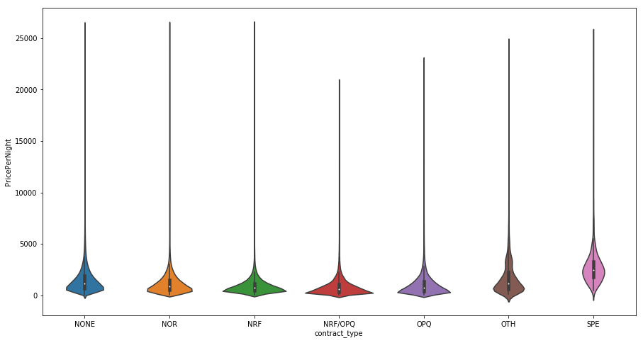

```python
# Violin plot describing the distribution of price per type of contract
plt.figure(figsize=(15,8))
sns.violinplot(x='contract_type', y='PricePerNight', data=df);
```

**NOR** - Normal

**NRF** - Non-Refundable

**NONE** - No Contract

**OPQ** - Opaque (Selling unsold travel inventory at a discounted price)

**NRF/OPQ** - Non-Refundable and Opaque

**SPE** - Special

**OTH** - Other

```python
df.groupby(["contract_type", "HotelStarRating"])['PricePerNight'].median().unstack()
```

| HotelStarRating contract_type | 1 | 2 | 3 | 4 | 5 |
| --- | --- | --- | --- | --- | --- |
| NONE | 438.0 | 897.0 | 893.0 | 1270.0 | 2159.0 |
| NOR | 402.0 | 659.0 | 766.0 | 1031.0 | 1538.0 |
| NRF | 294.0 | 471.0 | 677.0 | 858.5 | 1096.0 |
| NRF/OPQ | 179.5 | 398.0 | 345.0 | 740.0 | 1075.0 |
| OPQ | 170.0 | 513.0 | 636.0 | 778.0 | 1752.0 |
| OTH | NaN | 1196.5 | 862.5 | 658.0 | 1614.5 |
| SPE | NaN | NaN | NaN | 833.0 | 2495.0 |

```python
df.groupby(["contract_type"])['PricePerNight'].std().sort_values(ascending = False)
```

```
contract_type
SPE        1919.746662
OTH        1677.784047
NONE       1518.124754
NOR        1076.590732
OPQ        1050.667233
NRF/OPQ     829.380099
NRF         778.583374
Name: PricePerNight, dtype: float64
```

```python
df.groupby(["contract_type"])['PricePerNight'].count().sort_values(ascending = False)
```

```
contract_type
NOR        494504
NRF        128761
OPQ        123467
NONE       113059
NRF/OPQ     27095
OTH          2556
SPE          1068
Name: PricePerNight, dtype: int64
```

```python
df.groupby(["contract_type"])['PricePerNight'].max().sort_values(ascending = False)
```

```
contract_type
NRF        26469
NOR        26422
NONE       26245
SPE        24930
OTH        24247
OPQ        22929
NRF/OPQ    20782
Name: PricePerNight, dtype: int64
```

```python
# Regrouping and dummifying the contract type
df['contract_NOR'] = 0
df.loc[df.contract_type == 'NOR', 'contract_NOR'] = 1

df['contract_OPQ'] = 0
df.loc[(df.contract_type == 'OPQ')  | (df.contract_type == 'NRF/OPQ') , 'contract_OPQ'] = 1

df['contract_NRF'] = 0
df.loc[(df.contract_type == 'NRF')  | (df.contract_type == 'NRF/OPQ') , 'contract_NRF'] = 1

df['contract_UND'] = 0
df.loc[(df.contract_type == 'OTH')  | (df.contract_type == 'NONE') , 'contract_UND'] = 1

df['contract_SPE'] = 0
df.loc[(df.contract_type == 'SPE'), 'contract_SPE'] = 1
```

```python
# New feature for storing the contract deviation
df['contractDeviation'] = 1
df.loc[df.contract_type.isin(['OTH','NONE','SPE']),'contractDeviation'] = 5
```

#### Other Date Variables

```python
dateVar = ['creation_date_month', 'creation_date_day', 'creation_date_weekday',
           'arrival_date_day', 'arrival_date_weekday']
```

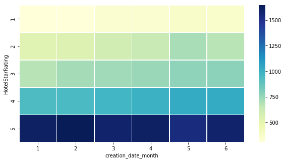

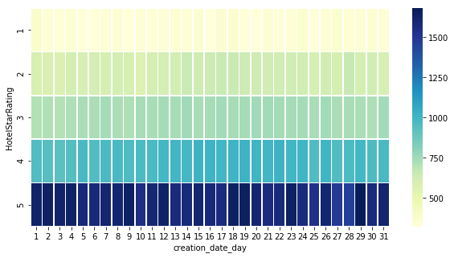

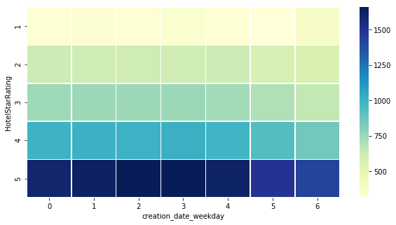

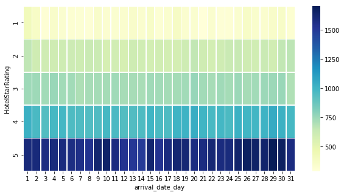

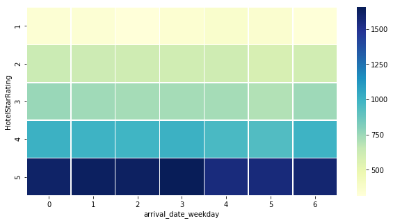

```python
for i, var in enumerate(dateVar):
    plt.figure(i,figsize=(10,5))
    sns.heatmap(df.groupby(["HotelStarRating",var])['PricePerNight'].median().unstack()
            ,linewidths=.5, cmap="YlGnBu")
```

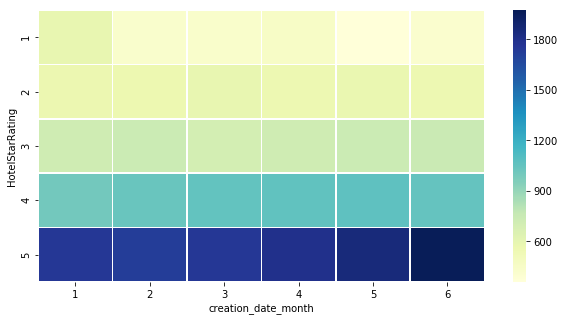

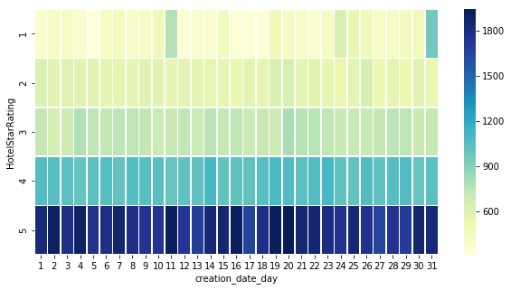

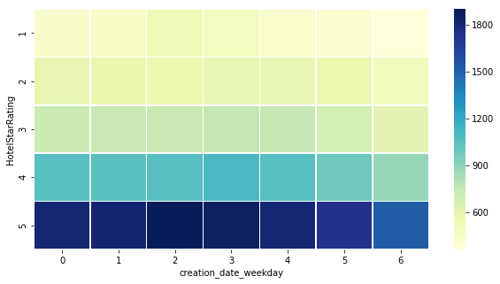

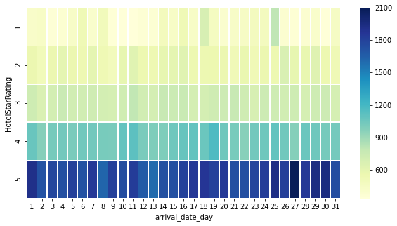

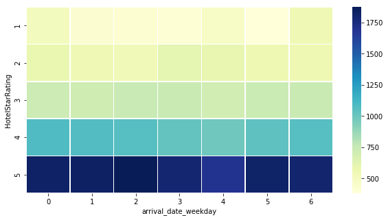

```python
for i, var in enumerate(dateVar):
    plt.figure(i,figsize=(10,5))
    sns.heatmap(df.groupby(["HotelStarRating",var])['PricePerNight'].std().unstack()
            ,linewidths=.5, cmap="YlGnBu")
```

Apart from month (analysed before) date Variables are not adding much value is not adding any additional Value to understand the median prices

#### Time Variables

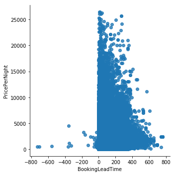

```python
# Scatter plot of price by 'BookingLeadTime'
sns.lmplot(x= 'BookingLeadTime', # Horizontal axis
           y= 'PricePerNight',   # Vertical axis
           data=df,              # Data source
           fit_reg=False,        # Don't fix a regression line
           );
```

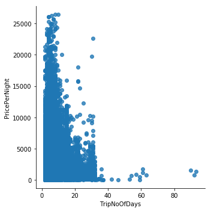

```python
# By Trip Days
sns.lmplot(x= 'TripNoOfDays',  # Horizontal axis
           y= 'PricePerNight', # Vertical axis
           data=df,            # Data source
           fit_reg=False,      # Don't fix a regression line
           );
```

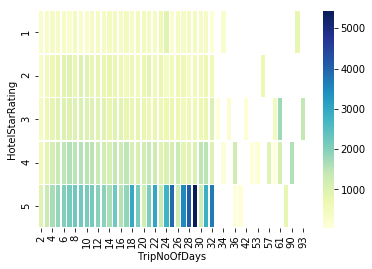

```python
sns.heatmap(df.groupby(["HotelStarRating",'TripNoOfDays'])['PricePerNight'].median().unstack()
            ,linewidths=.5, cmap="YlGnBu");
```

```python
# Binning the higher values of the variables 'TripNoOfDays'
df.loc[df.TripNoOfDays.isin(range(15,20)), 'TripNoOfDays'] = 15
df.loc[df.TripNoOfDays.isin(range(20,31)), 'TripNoOfDays'] = 25
df.loc[df.TripNoOfDays.isin(range(31,45)), 'TripNoOfDays'] = 40
df.loc[df.TripNoOfDays.isin(range(45,60)), 'TripNoOfDays'] = 50
df.loc[df.TripNoOfDays.isin(range(60,90)), 'TripNoOfDays'] = 80
df.loc[df.TripNoOfDays >= 90 , 'TripNoOfDays'] = 100

df.groupby(['TripNoOfDays'])['PricePerNight'].count()
```

```
TripNoOfDays
2      225664
3      165471
4      170521
5      120009
6       64704
7       35052
8       58145
9       11666
10       9493
11      11191
12       3777
13       2460
14       2374
15       7695
25       1949
40        327
50          6
80          3
100         3
Name: PricePerNight, dtype: int64
```

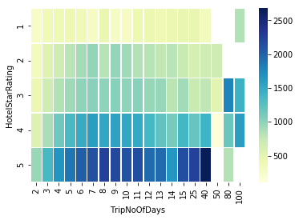

```python
sns.heatmap(df.groupby(["HotelStarRating",'TripNoOfDays'])['PricePerNight'].median().unstack()
            ,linewidths=.5, cmap="YlGnBu");
```

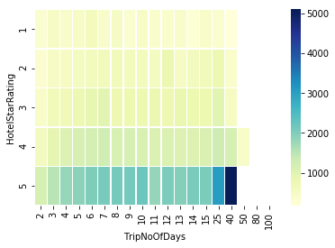

```python
sns.heatmap(df.groupby(["HotelStarRating",'TripNoOfDays'])['PricePerNight'].std().unstack()
            ,linewidths=.5, cmap="YlGnBu");
```

We can clearly see that time of the trip has an influence on the per night price. Specially the extreme high duration trips. Thus it would be good to bin the higher values of trip duration. Also provide added information on top of the trip duration by creating new variables that store a score based on the trip duration. The standard deviation reveals information on the propensity of a trip to have anomalous pricing. Thus we create new feature to score this propoensity as well.

```python
# New feature for deviation of price by duration
df['DurationDeviation'] = 1
df.loc[df.TripNoOfDays.isin(range(7,15)),'DurationDeviation'] = 5
df.loc[df.TripNoOfDays.isin(range(15,50)),'DurationDeviation'] = 25
df.loc[df.TripNoOfDays > 50 ,'DurationDeviation'] = 125
```

```python
# Ranking trip duration
df['durationType'] = 1
df.loc[df.TripNoOfDays.isin(range(7,12)), 'durationType'] = 20
df.loc[df.TripNoOfDays.isin(range(12,50)), 'durationType'] = 5
df.loc[df.TripNoOfDays > 50, 'durationType'] = 10
```

```python
df.groupby(['TripWeekends'])['PricePerNight'].count()
```

```
TripWeekends
0     267057
1     186751
2     382812
3      29288
4      19186
5       2521
6       1692
7        271
8        596
9        208
10       114
11         1
12         2
14         1
15         1
16         2
18         4
25         1
26         2
Name: PricePerNight, dtype: int64
```

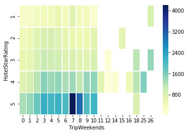

```python
sns.heatmap(df.groupby(["HotelStarRating",'TripWeekends'])['PricePerNight'].median().unstack()
            ,linewidths=.5, cmap="YlGnBu");
```

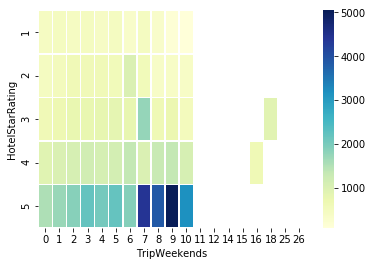

```python
sns.heatmap(df.groupby(["HotelStarRating",'TripWeekends'])['PricePerNight'].std().unstack()
            ,linewidths=.5, cmap="YlGnBu");
```

```python
# Treating trip weekends just like trip duration
df.loc[df.TripWeekends.isin(range(5,11)), 'TripWeekends'] = 5
df.loc[df.TripWeekends >= 11 , 'TripWeekends'] = 11
```

```python
df['WeekendIncluded'] = 0
df.loc[(df.TripWeekends > 0), 'WeekendIncluded' ] = 1
```

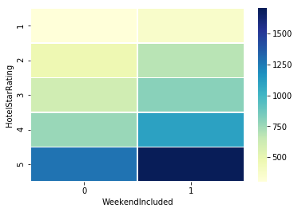

```python
sns.heatmap(df.groupby(["HotelStarRating",'WeekendIncluded'])['PricePerNight'].median().unstack()
            ,linewidths=.5, cmap="YlGnBu");
```

#### City

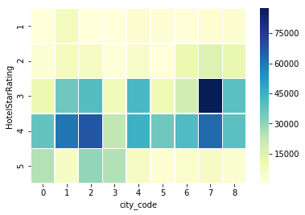

```python
sns.heatmap(df.groupby(['HotelStarRating',"city_code"])['PricePerNight'].count().unstack()
            ,linewidths=.5, cmap="YlGnBu");
```

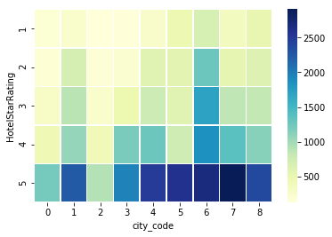

```python
sns.heatmap(df.groupby(['HotelStarRating',"city_code"])['PricePerNight'].median().unstack()
            ,linewidths=.5, cmap="YlGnBu");
```

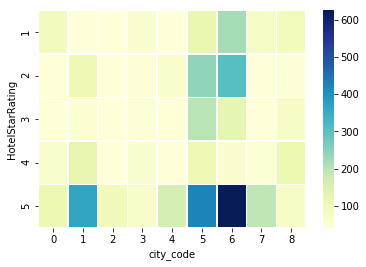

```python
sns.heatmap(df.groupby(['HotelStarRating',"city_code"])['PricePerNight'].min().unstack()
            ,linewidths=.5, cmap="YlGnBu");
```

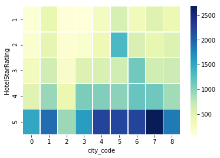

```python
sns.heatmap(df.groupby(['HotelStarRating',"city_code"])['PricePerNight'].std().unstack()
            ,linewidths=.5, cmap="YlGnBu");
```

From the heat map we can clearly identfy cities that have relatively higher prices. We can hence group the cities and rank them based on the 'cost of living' that can be deduced from the exploration

```python
# Rank the cities based on median prices
df['cityRank'] = 1
df.loc[df.city_code.isin([5,6]), 'cityRank'] = 9
df.loc[df.city_code.isin([1,4,7,8]), 'cityRank'] = 3

df['cityDeviation'] = 1
df.loc[df.city_code.isin([8,5,1]), 'cityDeviation'] = 9
df.loc[df.city_code.isin([7,6,1]), 'cityDeviation'] = 3
```

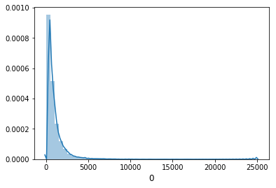

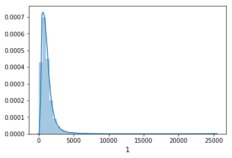

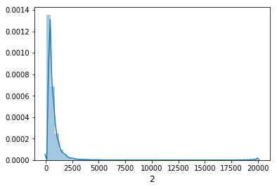

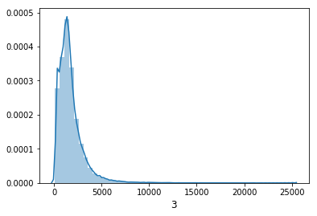

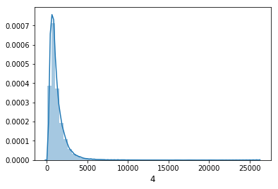

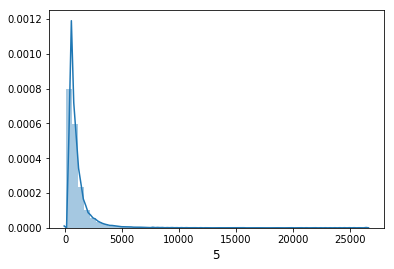

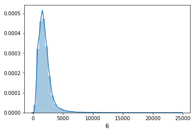

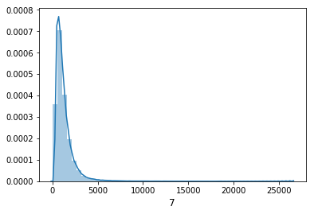

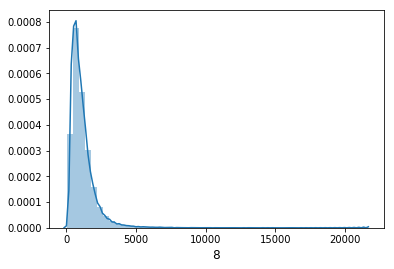

```python
# Plotting the distribution of the price per city
for i, city in enumerate(df.city_code.cat.categories):
    plt.figure(i)
    #sns.distplot(train_data.loc[:,col], bins= 2)
    sns.distplot(df.loc[(df.city_code == city),'PricePerNight'])
    plt.xlabel(city, fontsize=12)
```

```python
# New variable that takes into account the kurtosis for the previously plotted distributions
df['CityKurtosis'] = 0
for i, city in enumerate(df.city_code.cat.categories):
    df.loc[(df.city_code == city),'CityKurtosis'] = df.loc[(df.city_code == city),'PricePerNight'].kurtosis()
```

```python
df.CityKurtosis = df.CityKurtosis.astype('int')
```

#### Hotel Key

Though it makes sense to treat it just like contract, the information is already captured in the contractID and other hotel features. Thus it will not add any additional values

### Preparation and Transformation of Data Set

```python
df.head()
```

|  | hotel_hkey | contract_id_hkey | city_code | category_room | contract_type | room_type | meal_basis | star_rating | row_id | creation_date_month | ... | contract_NRF | contract_UND | contract_SPE | contractDeviation | DurationDeviation | durationType | WeekendIncluded | cityRank | cityDeviation | CityKurtosis |
| --- | --- | --- | --- | --- | --- | --- | --- | --- | --- | --- | --- | --- | --- | --- | --- | --- | --- | --- | --- | --- | --- |
| 0 | -8311839113995541010 | 3308171939935307043 | 1 | BL-6 | OPQ | APT | RO | APARTMENT | 0 | 5 | ... | 0 | 0 | 0 | 1 | 1 | 1 | 1 | 3 | 3 | 51 |
| 1 | -7782336419181110673 | -3269338087318960614 | 8 | ST | NOR | DBT | BB | HOTEL | 1 | 5 | ... | 0 | 0 | 0 | 1 | 1 | 1 | 1 | 3 | 9 | 29 |
| 2 | -8185637807857201025 | -7171383991101553094 | 6 | XX-KG-SU | NOR | DBL | RO | HOTEL | 2 | 5 | ... | 0 | 0 | 0 | 1 | 1 | 1 | 1 | 9 | 3 | 34 |
| 3 | 4398388086357359587 | 3421074771505167982 | 2 | ST | NONE | TWN | BB | HOTEL | 3 | 5 | ... | 0 | 1 | 0 | 5 | 1 | 1 | 1 | 1 | 1 | 57 |
| 4 | -7098207282290159573 | 7965439627984399332 | 7 | ST | NOR | DBT | RO | HOTEL | 4 | 5 | ... | 0 | 0 | 0 | 1 | 1 | 1 | 0 | 3 | 3 | 50 |

5 rows × 43 columns

```python
df = df.set_index('row_id')
```

```python
df.columns
```

```
Index(['hotel_hkey', 'contract_id_hkey', 'city_code', 'category_room',
       'contract_type', 'room_type', 'meal_basis', 'star_rating',
       'creation_date_month', 'creation_date_day', 'creation_date_weekday',
       'arrival_date_month', 'arrival_date_day', 'arrival_date_weekday',
       'departure_date_month', 'departure_date_day', 'departure_date_weekday',
       'TripNoOfDays', 'TripWorkingDays', 'TripWeekends', 'BookingLeadTime',
       'PricePerNight', 'ContractIdMean', 'priceDifbyContractMean',
       'HotelStarRating', 'MedianPriceByRoomType', 'monthRating',
       'categoryRoomPriceRank', 'mealBasisDeviation', 'mealBasisRank',
       'contract_NOR', 'contract_OPQ', 'contract_NRF', 'contract_UND',
       'contract_SPE', 'contractDeviation', 'DurationDeviation',
       'durationType', 'WeekendIncluded', 'cityRank', 'cityDeviation',
       'CityKurtosis'],
      dtype='object')
```

```python
df.dtypes
```

```
hotel_hkey                   int64
contract_id_hkey             int64
city_code                 category
category_room             category
contract_type             category
room_type                 category
meal_basis                category
star_rating                 object
creation_date_month       category
creation_date_day         category
creation_date_weekday     category
arrival_date_month        category
arrival_date_day          category
arrival_date_weekday      category
departure_date_month      category
departure_date_day        category
departure_date_weekday    category
TripNoOfDays                 int64
TripWorkingDays              int64
TripWeekends                 int64
BookingLeadTime              int64
PricePerNight                int64
ContractIdMean             float64
priceDifbyContractMean     float64
HotelStarRating              int32
MedianPriceByRoomType      float64
monthRating                  int64
categoryRoomPriceRank        int64
mealBasisDeviation           int64
mealBasisRank                int64
contract_NOR                 int64
contract_OPQ                 int64
contract_NRF                 int64
contract_UND                 int64
contract_SPE                 int64
contractDeviation            int64
DurationDeviation            int64
durationType                 int64
WeekendIncluded              int64
cityRank                     int64
cityDeviation                int64
CityKurtosis                 int32
dtype: object
```

```python
df.MedianPriceByRoomType = df.MedianPriceByRoomType.astype('int')
df.ContractIdMean = df.ContractIdMean.astype('int')
df.priceDifbyContractMean = df.priceDifbyContractMean.astype('int')
```

```python
df.shape
```

```
(890510, 42)
```

```python
# Dropping variables that are no longer needed
df = df.drop(['hotel_hkey', 'contract_id_hkey', 'city_code', 'category_room',
       'contract_type', 'room_type', 'meal_basis', 'star_rating',
       'creation_date_month', 'creation_date_day', 'creation_date_weekday',
       'arrival_date_month', 'arrival_date_day', 'arrival_date_weekday',
       'departure_date_month', 'departure_date_day', 'departure_date_weekday',
       ],axis =1)
```

```python
df.head()
```

| row_id | TripNoOfDays | TripWorkingDays | TripWeekends | BookingLeadTime | PricePerNight | ContractIdMean | priceDifbyContractMean | HotelStarRating | MedianPriceByRoomType | monthRating | ... | contract_NRF | contract_UND | contract_SPE | contractDeviation | DurationDeviation | durationType | WeekendIncluded | cityRank | cityDeviation | CityKurtosis |
| --- | --- | --- | --- | --- | --- | --- | --- | --- | --- | --- | --- | --- | --- | --- | --- | --- | --- | --- | --- | --- | --- |
| 0 | 6 | 4 | 2 | 39 | 2365 | 1434 | 930 | 4 | 1200 | 25 | ... | 0 | 0 | 0 | 1 | 1 | 1 | 1 | 3 | 3 | 51 |
| 1 | 5 | 3 | 2 | 59 | 711 | 693 | 17 | 1 | 628 | 75 | ... | 0 | 0 | 0 | 1 | 1 | 1 | 1 | 3 | 9 | 29 |
| 2 | 6 | 4 | 2 | 2 | 2886 | 3324 | -438 | 5 | 1027 | 5 | ... | 0 | 0 | 0 | 1 | 1 | 1 | 1 | 9 | 3 | 34 |
| 3 | 4 | 2 | 2 | 17 | 830 | 1582 | -752 | 3 | 780 | 25 | ... | 0 | 1 | 0 | 5 | 1 | 1 | 1 | 1 | 1 | 57 |
| 4 | 4 | 4 | 0 | 20 | 646 | 518 | 127 | 3 | 628 | 25 | ... | 0 | 0 | 0 | 1 | 1 | 1 | 0 | 3 | 3 | 50 |

5 rows × 25 columns

So finally we have transformed the entire categorical data set into a purely numerical one. This way we can go ahead and apply statistical rules and models based on continous data

```python
# Saving the transformed dataset before diving into outlier detection
df.to_csv('TransformedData.csv', sep=',', header=True)
```

### OUTLIER/ANOMALY DETECTION

```python
df.head()
```

| row_id | TripNoOfDays | TripWorkingDays | TripWeekends | BookingLeadTime | PricePerNight | ContractIdMean | priceDifbyContractMean | HotelStarRating | MedianPriceByRoomType | monthRating | ... | contract_NRF | contract_UND | contract_SPE | contractDeviation | DurationDeviation | durationType | WeekendIncluded | cityRank | cityDeviation | CityKurtosis |
| --- | --- | --- | --- | --- | --- | --- | --- | --- | --- | --- | --- | --- | --- | --- | --- | --- | --- | --- | --- | --- | --- |
| 0 | 6 | 4 | 2 | 39 | 2365 | 1434 | 930 | 4 | 1200 | 25 | ... | 0 | 0 | 0 | 1 | 1 | 1 | 1 | 3 | 3 | 51 |
| 1 | 5 | 3 | 2 | 59 | 711 | 693 | 17 | 1 | 628 | 75 | ... | 0 | 0 | 0 | 1 | 1 | 1 | 1 | 3 | 9 | 29 |
| 2 | 6 | 4 | 2 | 2 | 2886 | 3324 | -438 | 5 | 1027 | 5 | ... | 0 | 0 | 0 | 1 | 1 | 1 | 1 | 9 | 3 | 34 |
| 3 | 4 | 2 | 2 | 17 | 830 | 1582 | -752 | 3 | 780 | 25 | ... | 0 | 1 | 0 | 5 | 1 | 1 | 1 | 1 | 1 | 57 |
| 4 | 4 | 4 | 0 | 20 | 646 | 518 | 127 | 3 | 628 | 25 | ... | 0 | 0 | 0 | 1 | 1 | 1 | 0 | 3 | 3 | 50 |

5 rows × 25 columns

```python
df.columns
```

```
Index(['TripNoOfDays', 'TripWorkingDays', 'TripWeekends', 'BookingLeadTime',
       'PricePerNight', 'ContractIdMean', 'priceDifbyContractMean',
       'HotelStarRating', 'MedianPriceByRoomType', 'monthRating',
       'categoryRoomPriceRank', 'mealBasisDeviation', 'mealBasisRank',
       'contract_NOR', 'contract_OPQ', 'contract_NRF', 'contract_UND',
       'contract_SPE', 'contractDeviation', 'DurationDeviation',
       'durationType', 'WeekendIncluded', 'cityRank', 'cityDeviation',
       'CityKurtosis'],
      dtype='object')
```

As mentioned earlier we will proceed with a 2 fold process here. First we will create outlier score based on the features that explain the deviation of the price from the expected mean or median. This will be used to detect price points which have a high probability of being anomalouos. The actual price recorded will also be taken into consideration while making this criteria. The second approach will use clustering and regression to group similar bookings together and define outliers based on regression scores and residuals for each of fthe clusters

```python
# Scaling dataset
standard_scaler = preprocessing.StandardScaler()
np_scaled = standard_scaler.fit_transform(df)
df_scaled = pd.DataFrame(np_scaled, index=df.index, columns=df.columns)
```

```python
df_scaled.head()
```

| row_id | TripNoOfDays | TripWorkingDays | TripWeekends | BookingLeadTime | PricePerNight | ContractIdMean | priceDifbyContractMean | HotelStarRating | MedianPriceByRoomType | monthRating | ... | contract_NRF | contract_UND | contract_SPE | contractDeviation | DurationDeviation | durationType | WeekendIncluded | cityRank | cityDeviation | CityKurtosis |
| --- | --- | --- | --- | --- | --- | --- | --- | --- | --- | --- | --- | --- | --- | --- | --- | --- | --- | --- | --- | --- | --- |
| 0 | 0.575838 | 0.413620 | 0.690505 | -0.317700 | 1.063062 | 0.350324 | 1.104157 | 0.473183 | 1.049980 | 0.049552 | ... | -0.460596 | -0.386265 | -0.034652 | -0.388313 | -0.304524 | -0.418327 | 0.654486 | -0.087514 | -0.045363 | 0.607779 |
| 1 | 0.210293 | -0.063525 | 0.690505 | -0.029443 | -0.417529 | -0.659671 | 0.020082 | -3.017766 | -1.111124 | 1.881722 | ... | -0.460596 | -0.386265 | -0.034652 | -0.388313 | -0.304524 | -0.418327 | 0.654486 | -0.087514 | 2.139355 | -1.627399 |
| 2 | 0.575838 | 0.413620 | 0.690505 | -0.850975 | 1.529439 | 2.926425 | -0.520175 | 1.636832 | 0.396359 | -0.683316 | ... | -0.460596 | -0.386265 | -0.034652 | -0.388313 | -0.304524 | -0.418327 | 0.654486 | 2.311026 | -0.045363 | -1.119404 |
| 3 | -0.155253 | -0.540669 | 0.690505 | -0.634782 | -0.311005 | 0.552051 | -0.893011 | -0.690467 | -0.536844 | 0.049552 | ... | -0.460596 | 2.588894 | -0.034652 | 2.575243 | -0.304524 | -0.418327 | 0.654486 | -0.887027 | -0.773602 | 1.217373 |
| 4 | -0.155253 | 0.413620 | -1.240497 | -0.591544 | -0.475714 | -0.898199 | 0.150693 | -0.690467 | -1.111124 | 0.049552 | ... | -0.460596 | -0.386265 | -0.034652 | -0.388313 | -0.304524 | -0.418327 | -1.527917 | -0.087514 | -0.045363 | 0.506180 |

5 rows × 25 columns

#### Statistical and Visualization Approach

```python
# Take the deviation columns and create an outlier score
df_scaled['outlierScore'] = ((df_scaled.priceDifbyContractMean*100) *
                            ((df_scaled.mealBasisDeviation + df_scaled.contractDeviation +
                            df_scaled.DurationDeviation + df_scaled.cityDeviation + df_scaled.CityKurtosis) * 10 ))
df_scaled['outlierScore'] = preprocessing.scale(df_scaled['outlierScore'])
```

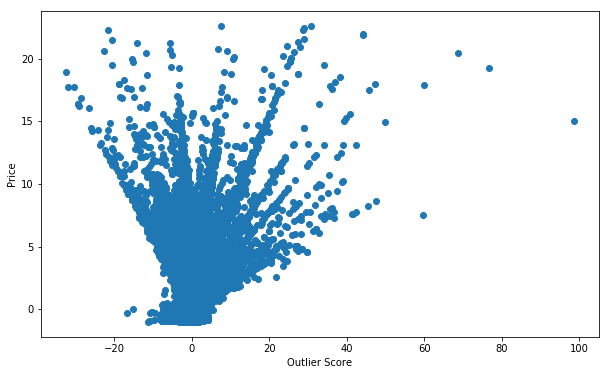

```python
# Scatter Plot of the outlier score over price
plt.figure(figsize=(10,6))
plt.scatter(df_scaled.outlierScore,df_scaled.PricePerNight)
plt.ylabel('Price')
plt.xlabel('Outlier Score');
```

The dispersion of the data points shows clearly that extremely high outlier scores on either side can be treated as anomalies. Thus high outlier score and high prices on the extreme ends of the distribution (including the negetive side of outlier score) can be tagged as anomalies.

```python
## Returning the outliers from both sides of the distribution

# On the positive side
print(df_scaled.loc[(df_scaled.outlierScore > 30), 'PricePerNight'].size) # 10
print(df_scaled.loc[((df_scaled.outlierScore > 20) & (df_scaled.outlierScore < 30)) & (df_scaled.PricePerNight > 12), 'PricePerNight'].size) # 10

# On the negative side
print(df_scaled.loc[(df_scaled.outlierScore < -15) & (df_scaled.PricePerNight < 5), 'PricePerNight'].size)
print(df_scaled.loc[(df_scaled.outlierScore < -15) & (df_scaled.PricePerNight > 15), 'PricePerNight'].size)
```

```
58
41
2
22
```

The boundary conditions are set based on the distribution observed in the scatter plot above and also keeping tight rules to allow for lower probability of False positives

```python
# New Data Frame containing the previously spotted anomalies
df_anomaly3 = pd.DataFrame( df_scaled.loc[
                   (df_scaled.outlierScore > 30)
                 | (((df_scaled.outlierScore > 20) & (df_scaled.outlierScore < 30)) & (df_scaled.PricePerNight > 12))
                 | ((df_scaled.outlierScore < -15) & (df_scaled.PricePerNight < 5))
                 | ((df_scaled.outlierScore < -15) & (df_scaled.PricePerNight > 15))
                  , 'PricePerNight'])
```

```python
df_anomaly3.shape
```

```
(123, 1)
```

```python
df_scaled = df_scaled.loc[df_scaled.index.isin(df_anomaly3.index) == False , :]
```

```python
df_scaled.columns
```

```
Index(['TripNoOfDays', 'TripWorkingDays', 'TripWeekends', 'BookingLeadTime',
       'PricePerNight', 'ContractIdMean', 'priceDifbyContractMean',
       'HotelStarRating', 'MedianPriceByRoomType', 'monthRating',
       'categoryRoomPriceRank', 'mealBasisDeviation', 'mealBasisRank',
       'contract_NOR', 'contract_OPQ', 'contract_NRF', 'contract_UND',
       'contract_SPE', 'contractDeviation', 'DurationDeviation',
       'durationType', 'WeekendIncluded', 'cityRank', 'cityDeviation',
       'CityKurtosis', 'outlierScore'],
      dtype='object')
```

```python
# Removing the variables that we will not use anymore
df_scaled = df_scaled.drop(['priceDifbyContractMean' , 'mealBasisDeviation',
                            'contractDeviation', 'DurationDeviation', 'cityDeviation',
                            'CityKurtosis', 'outlierScore'], axis = 1)
```

#### Cluster and Regression Approach

```python
data = df_scaled
```

```python
PricePerNight = data.PricePerNight
```

```python
data = data.drop(['PricePerNight'], axis =1 )
```

```python
# Take useful features and standardize them
standard_scaler = preprocessing.StandardScaler()
np_scaled = standard_scaler.fit_transform(data)
data = pd.DataFrame(np_scaled, index=data.index)
```

```python
columNames = df_scaled.columns.drop(['PricePerNight'])
data.columns = columNames
```

```python
print(data.shape)
data.head()
```

```
(890387, 18)
```

| row_id | TripNoOfDays | TripWorkingDays | TripWeekends | BookingLeadTime | ContractIdMean | HotelStarRating | MedianPriceByRoomType | monthRating | categoryRoomPriceRank | mealBasisRank | contract_NOR | contract_OPQ | contract_NRF | contract_UND | contract_SPE | durationType | WeekendIncluded | cityRank |
| --- | --- | --- | --- | --- | --- | --- | --- | --- | --- | --- | --- | --- | --- | --- | --- | --- | --- | --- |
| 0 | 0.577039 | 0.414300 | 0.690784 | -0.317656 | 0.350566 | 0.473360 | 1.050173 | 0.049580 | 1.711563 | -0.649944 | -1.117573 | 2.216770 | -0.460626 | -0.386133 | -0.034654 | -0.418282 | 0.654527 | -0.087458 |
| 1 | 0.210898 | -0.063366 | 0.690784 | -0.029379 | -0.659638 | -3.017772 | -1.111077 | 1.881764 | -0.277998 | -0.055756 | 0.894796 | -0.451107 | -0.460626 | -0.386133 | -0.034654 | -0.418282 | 0.654527 | -0.087458 |
| 2 | 0.577039 | 0.414300 | 0.690784 | -0.850969 | 2.927198 | 1.637071 | 0.396508 | -0.683293 | 0.219392 | -0.649944 | 0.894796 | -0.451107 | -0.460626 | -0.386133 | -0.034654 | -0.418282 | 0.654527 | 2.311175 |
| 3 | -0.155242 | -0.541032 | 0.690784 | -0.634761 | 0.552334 | -0.690350 | -0.536759 | 0.049580 | -0.277998 | -0.055756 | -1.117573 | -0.451107 | -0.460626 | 2.589783 | -0.034654 | -0.418282 | 0.654527 | -0.887003 |
| 4 | -0.155242 | 0.414300 | -1.240616 | -0.591519 | -0.898215 | -0.690350 | -1.111077 | 0.049580 | -0.277998 | -0.649944 | 0.894796 | -0.451107 | -0.460626 | -0.386133 | -0.034654 | -0.418282 | -1.527820 | -0.087458 |

We begin with PCA to capture the variations as much as possible without having to perform arbitrary feature selection. We have a total of 18 featuers (hence 18 PC) of which we will retain enough to capture atleas 80% of the variance in the data

```python
## PCA
# reduce to 10 importants features
pca = PCA(n_components=10)
data_PCA = pca.fit_transform(data)
data_PCA = pd.DataFrame(data_PCA, index=data.index)
```

```python
# standardize these 10 new features
standard_scaler = preprocessing.StandardScaler()
np_scaled = standard_scaler.fit_transform(data_PCA)
data_PCA = pd.DataFrame(np_scaled, index=data_PCA.index)
```

```python
data_PCA.head()
```

| row_id | 0 | 1 | 2 | 3 | 4 | 5 | 6 | 7 | 8 | 9 |
| --- | --- | --- | --- | --- | --- | --- | --- | --- | --- | --- |
| 0 | 0.479205 | 0.703927 | 1.412341 | 0.663251 | -0.283966 | -0.278070 | 0.263046 | -0.793438 | 1.953229 | 0.969553 |
| 1 | 0.275501 | -1.455008 | -0.844496 | -1.288080 | -0.840512 | -0.986995 | -0.425414 | 0.711756 | 0.307807 | -1.314518 |
| 2 | 0.718216 | 1.501056 | -0.640290 | -0.284785 | -0.594555 | 1.398499 | 1.415269 | -1.124944 | 0.600015 | 0.788215 |
| 3 | -0.122936 | 0.314188 | 0.709994 | -0.391187 | -0.749486 | 1.168437 | -2.242094 | 0.921336 | -0.631974 | -0.721845 |
| 4 | -0.780175 | -0.800730 | -1.064960 | -0.653402 | 1.341318 | -0.020423 | 0.128515 | 0.138521 | 0.245043 | 0.060215 |

```python
pca.explained_variance_ratio_.sum()
```

```
0.8318495270555261
```

```python
data_PCA.shape
```

```
(890387, 10)
```

To decide on the clustering we will go by the standard elbow curve approach. However, we need to ensure that we chose < 10 clusters (since PC = 10)

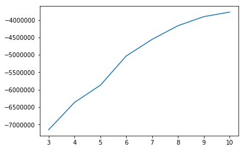

```python
# Calculate with different number of centroids to see the loss-plot (elbow method)
n_cluster = range(3, 11)
kmeans = [KMeans(n_clusters=i).fit(data_PCA) for i in n_cluster]
scores = [kmeans[i].score(data_PCA) for i in range(len(kmeans))]
fig, ax = plt.subplots()
ax.plot(n_cluster, scores)
plt.show()
```

```python
# 8 clusters (start at 3)
km = kmeans[5]
```

```python
km
```

```
KMeans(algorithm='auto', copy_x=True, init='k-means++', max_iter=300,
    n_clusters=8, n_init=10, n_jobs=1, precompute_distances='auto',
    random_state=None, tol=0.0001, verbose=0)
```

```python
data_PCA['BookingCluster'] = km.predict(data_PCA)
#df['principal_feature1'] = data[0]
#df['principal_feature2'] = data[1]
#df['cluster'].value_counts()
```

```python
data_PCA.head()
```

| row_id | 0 | 1 | 2 | 3 | 4 | 5 | 6 | 7 | 8 | 9 | BookingCluster |
| --- | --- | --- | --- | --- | --- | --- | --- | --- | --- | --- | --- |
| 0 | 0.479205 | 0.703927 | 1.412341 | 0.663251 | -0.283966 | -0.278070 | 0.263046 | -0.793438 | 1.953229 | 0.969553 | 2 |
| 1 | 0.275501 | -1.455008 | -0.844496 | -1.288080 | -0.840512 | -0.986995 | -0.425414 | 0.711756 | 0.307807 | -1.314518 | 5 |
| 2 | 0.718216 | 1.501056 | -0.640290 | -0.284785 | -0.594555 | 1.398499 | 1.415269 | -1.124944 | 0.600015 | 0.788215 | 5 |
| 3 | -0.122936 | 0.314188 | 0.709994 | -0.391187 | -0.749486 | 1.168437 | -2.242094 | 0.921336 | -0.631974 | -0.721845 | 1 |
| 4 | -0.780175 | -0.800730 | -1.064960 | -0.653402 | 1.341318 | -0.020423 | 0.128515 | 0.138521 | 0.245043 | 0.060215 | 3 |

```python
data_PCA.groupby(['BookingCluster']).size()
```

```
BookingCluster
0    125067
1    110928
2    133783
3    134420
4     84795
5    243321
6     57005
7      1068
dtype: int64
```

```python
data_PCA['PricePerNight'] = PricePerNight
```